# hw8_XianjieQue

XianjieQue

2025-04-13

### load packages

```r
library(ggplot2)
library(e1071)
library(ISLR)
library(tidyverse)
```

### Conceptual: 1 (a) Sketch the hyperplane 1 + 3X1 − X2 = 0

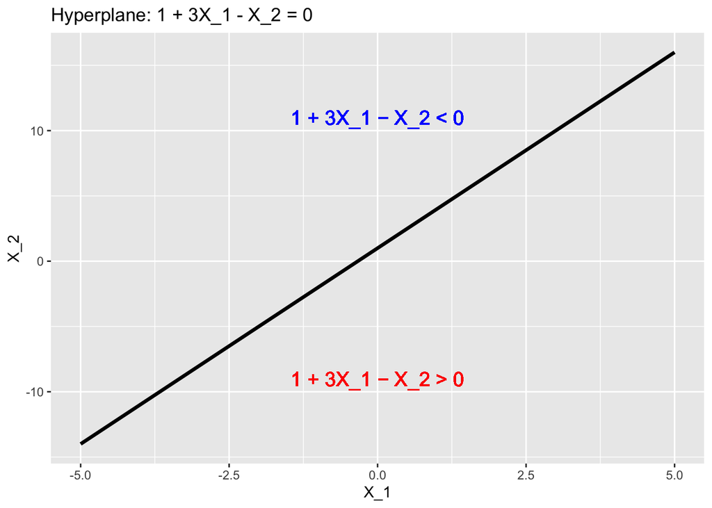

```r
x_vals <- seq(-5, 5, length.out = 200)
hyperplane1 <- data.frame(
  X1 = x_vals,
  X2 = 1 + 3 * x_vals
)

ggplot(hyperplane1, aes(x = X1, y = X2)) +
  geom_line(color = "black", size = 1.2) +
  geom_text(aes(x = 0, y = 1 + 3*(0) - 10, label = "1 + 3X_1 − X_2 > 0"), color = "red", size = 5) +
  geom_text(aes(x = 0, y = 1 + 3*(0) + 10, label = "1 + 3X_1 − X_2 < 0"), color = "blue", size = 5) +
  labs(title = "Hyperplane: 1 + 3X_1 - X_2 = 0",
       x = "X_1", y = "X_2")
```

### Conceptual: 1 (b) sketch the hyperplane −2 + X1 + 2X2 = 0

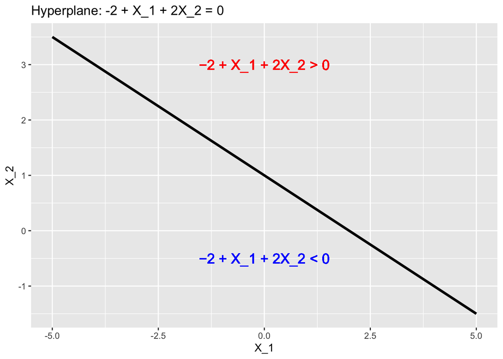

```r
hyperplane2 <- data.frame(
  X1 = x_vals,
  X2 = (-2 + x_vals) / -2
)

ggplot(hyperplane2, aes(x = X1, y = X2)) +
  geom_line(color = "black", size = 1.2) +
  geom_text(aes(x = 0, y = (-2 + (0)) / -2 + 2, label = "−2 + X_1 + 2X_2 > 0"), color = "red", size = 5) +
  geom_text(aes(x = 0, y = (-2 + (0)) / -2 - 1.5, label = "−2 + X_1 + 2X_2 < 0"), color = "blue", size = 5) +
  labs(title = "Hyperplane: -2 + X_1 + 2X_2 = 0",
       x = "X_1", y = "X_2")
```

### Conceptual: 2 (a)

Sketch the curve $(1 + X_1)^2 + (2 - X_2)^2 = 4$

This is a circle centered at (−1,2) with radius 2.

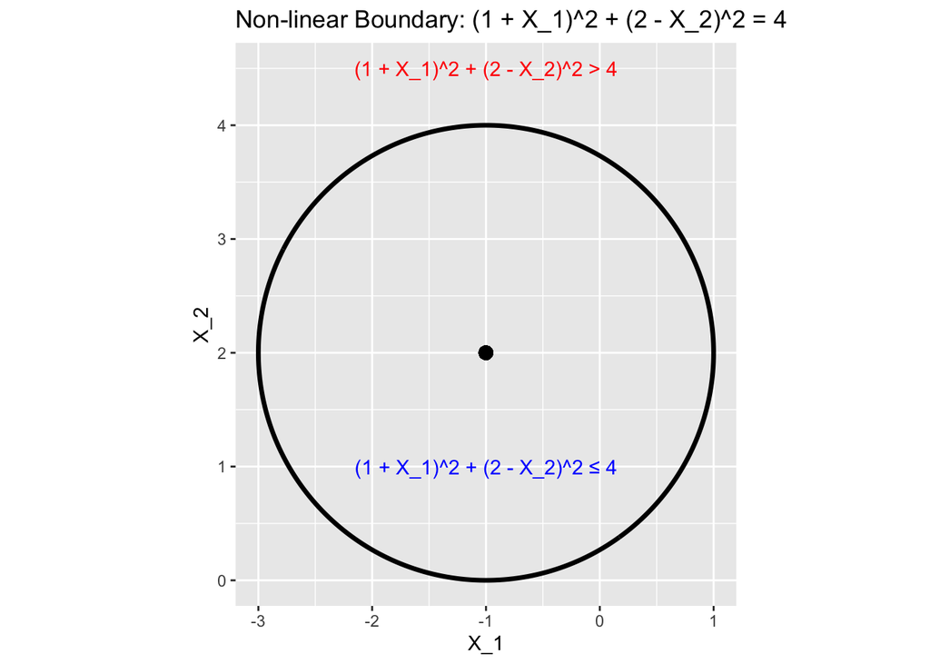

```r
theta <- seq(0, 2*pi, length.out = 300)
circle <- data.frame(
  X1 = -1 + 2 * cos(theta),
  X2 = 2 + 2 * sin(theta)
)

ggplot(circle, aes(x = X1, y = X2)) +
  geom_path(color = "black", size = 1.2) +
  geom_point(aes(x = -1, y = 2), color = "black", size = 3) +
  annotate("text", x = -1, y = 4.5, label = "(1 + X_1)^2 + (2 - X_2)^2 > 4", color = "red") +
  annotate("text", x = -1, y = 1, label = "(1 + X_1)^2 + (2 - X_2)^2 ≤ 4", color = "blue") +
  labs(title = "Non-linear Boundary: (1 + X_1)^2 + (2 - X_2)^2 = 4",
       x = "X_1", y = "X_2") +
  coord_fixed()
```

### Conceptual: 2 (b)

Inside or on the circle: $(1 + X_1)^2 + (2 - X_2)^2 ≤ 4$

The points are in blue

Outside the circle: $(1 + X_1)^2 + (2 - X_2)^2 > 4$

The points are in red

### Conceptual: 2 (c)

Classifier rule: assign to red if $(1 + X_1)^2 + (2 - X_2)^2 > 4$, otherwise blue.

(0, 0) (2, 2) (3, 8) are classified to red

(−1, 1) is classified to blue

```r
points_to_check <- data.frame(
  X1 = c(0, -1, 2, 3),
  X2 = c(0, 1, 2, 8)
)

points_to_check$result <- (1 + points_to_check$X1)^2 + (2 - points_to_check$X2)^2
points_to_check$class <- ifelse(points_to_check$result > 4, "Red", "Blue")
points_to_check
```

```
##   X1 X2 result class
## 1  0  0      5   Red
## 2 -1  1      1  Blue
## 3  2  2      9   Red
## 4  3  8     52   Red
```

### Conceptual: 2 (d)

The expression $(1 + X_1)^2 + (2 - X_2)^2 = 4$ expands to:

$$(1 + X_1)^2 + (2 − X_2)^2 \\ = X_1^2 + 2X_1 + 1 + 4 − 4X_2 + X_2^2 \\ =
X_1^2 + X_2^2 + 2X_1 - 4X_2 + 5$$
This is non-linear in terms of $X_1$ and $X_2$, but linear in the extended feature space including $X_1^2$, $X_2^2$, $X_1$, $X_2$.

For example, we can define:

$$Z_1 = X_1 \\ Z_2 = X_2 \\ Z_3 = X_1^2 \\ Z_4 = X_2^2$$

the boundary becomes $Z_3 + Z_4 + 2Z_1 - 4Z_2 + 5$, and it is linear in $Z_1$, $Z_2$, $Z_3$, $Z_4$.

### Applied: 7 (a) Create binary variable for high/low gas mileage

```r
set.seed(8)

Auto <- na.omit(Auto)
Auto$mpg01 <- ifelse(Auto$mpg > median(Auto$mpg), 1, 0)

# Prepare data: remove mpg, name
Auto_svm <- Auto %>% select(-mpg, -name)

Auto_svm$mpg01 <- as.factor(Auto_svm$mpg01)
```

### Applied: 7 (b) Linear SVM with different cost values

From the output, the optimal cost value is 10, and the corresponding best performance (error) is 0.08679487

Overall, the CV_Error is in the range 0.087–0.13, indicates that the test error is about 9%~13%, which means that the correct prediction ratio on the test set is about 87%~91%, which is a good performance.

From the trend of change, as the cost increases (the penalty increases), the error decreases at first and then increases, then decreases again, till it reaches 0.087 at cost = 10, then stay stable.

Low cost values may under-penalize misclassifications, leading to wider margins and higher error.

Lowest error values appear at cost = 10 and above — indicating that with higher cost values, the classifier penalizes misclassifications more and forms tighter decision boundaries, improving accuracy.

```r
cost_values <- c(0.001, 0.01, 0.1, 1, 5, 10, 100, 1000)

tune.out.linear <- tune(svm, mpg01 ~ ., data = Auto_svm, kernel = "linear",
                        ranges = list(cost = cost_values))
print(summary(tune.out.linear))
```

```
##
## Parameter tuning of 'svm':
##
## - sampling method: 10-fold cross validation
##
## - best parameters:
##  cost
##    10
##
## - best performance: 0.08679487
##
## - Detailed performance results:
##    cost      error dispersion
## 1 1e-03 0.13250000 0.06984144
## 2 1e-02 0.08929487 0.03230957
## 3 1e-01 0.09179487 0.02980107
## 4 1e+00 0.08929487 0.05120725
## 5 5e+00 0.08929487 0.05398508
## 6 1e+01 0.08679487 0.05137740
## 7 1e+02 0.08679487 0.05137740
## 8 1e+03 0.08679487 0.05137740
```

### Applied: 7 (c) Radial and Polynomial Kernel SVMs

For Radial Kernel SVM:

The result suggests that the model performs best with small gamma and moderate cost.

When cost = 0.001 or 0.01, regardless of gamma, the model consistently performs poorly (CV error up to 0.57).

This suggests the model is too constrained to find a meaningful boundary between classes.

Some combinations show higher CV error likely due to overfitting:

When gamma = 0.5 and cost is very large (1000), the CV error increases to 0.11

Similarly, with gamma = 1.00 and high cost, CV error also increases

This indicates that the model becomes too flexible and fits the training data too closely, losing some generalization.

```r
# Radial kernel
tune.out.radial <- tune(svm, mpg01 ~ ., data = Auto_svm, kernel = "radial",
                        ranges = list(cost = cost_values,
                                      gamma = c(0.5, 1, 2, 3, 4)))
print(summary(tune.out.radial))
```

```
##
## Parameter tuning of 'svm':
##
## - sampling method: 10-fold cross validation
##
## - best parameters:
##  cost gamma
##     1     1
##
## - best performance: 0.06660256
##
## - Detailed performance results:
##     cost gamma      error dispersion
## 1  1e-03   0.5 0.55096154 0.04884454
## 2  1e-02   0.5 0.55096154 0.04884454
```

[output cut: 38 more lines]

### Applied: 7 (c) Radial and Polynomial Kernel SVMs

For Polynomial Kernel SVM:

The result suggests that a degree-3 polynomial kernel with a moderate cost achieves the best performance.

With high degree and high cost, error increases again. For example:

Degree = 3, Cost = 1000, CV Error = 0.092

This indicates the model is too flexible and overfits the training data.

```r
# Polynomial kernel
tune.out.poly <- tune(svm, mpg01 ~ ., data = Auto_svm, kernel = "polynomial",
                        ranges = list(cost = cost_values,
                                      degree = c(1, 2, 3, 4, 5)))
print(summary(tune.out.poly))
```

```
##
## Parameter tuning of 'svm':
##
## - sampling method: 10-fold cross validation
##
## - best parameters:
##  cost degree
##    10      3
##
## - best performance: 0.08166667
##
## - Detailed performance results:
##     cost degree      error dispersion
## 1  1e-03      1 0.57410256 0.04680238
## 2  1e-02      1 0.12743590 0.06866778
```

[output cut: 38 more lines]

### Applied: 7 (d) Plot

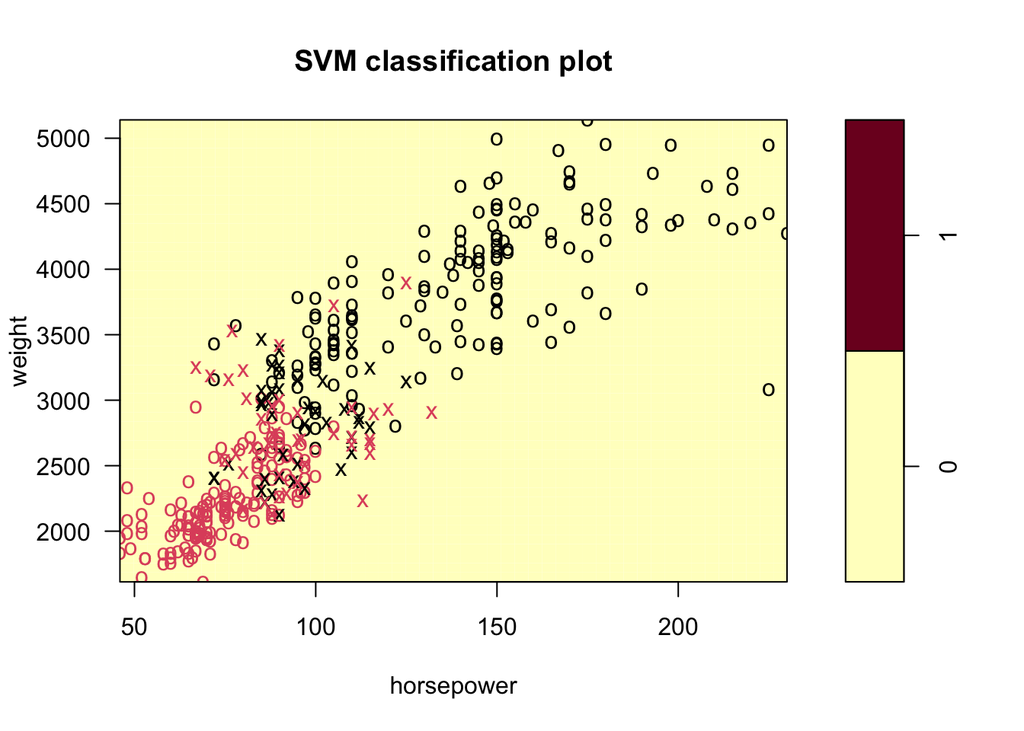

```r
# Linear
plot(tune.out.linear$best.model, Auto_svm, weight ~ horsepower)
```

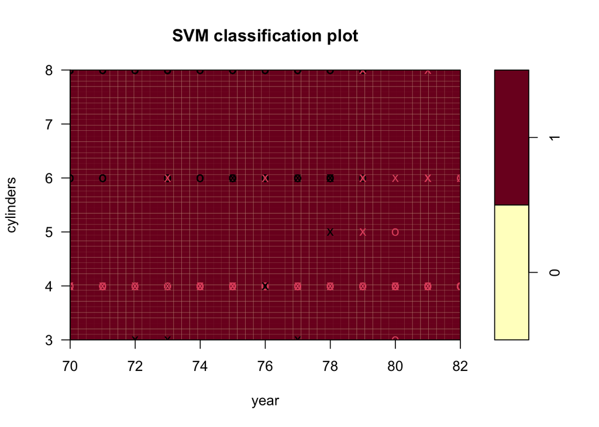

```r
plot(tune.out.linear$best.model, Auto_svm, cylinders ~ year)
```

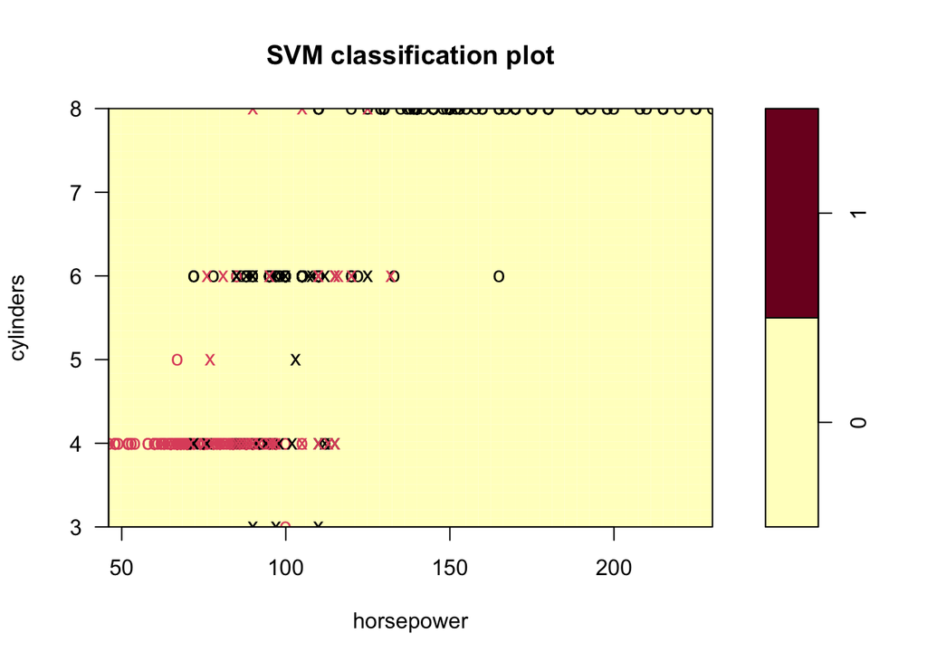

```r
plot(tune.out.linear$best.model, Auto_svm, cylinders ~ horsepower)
```

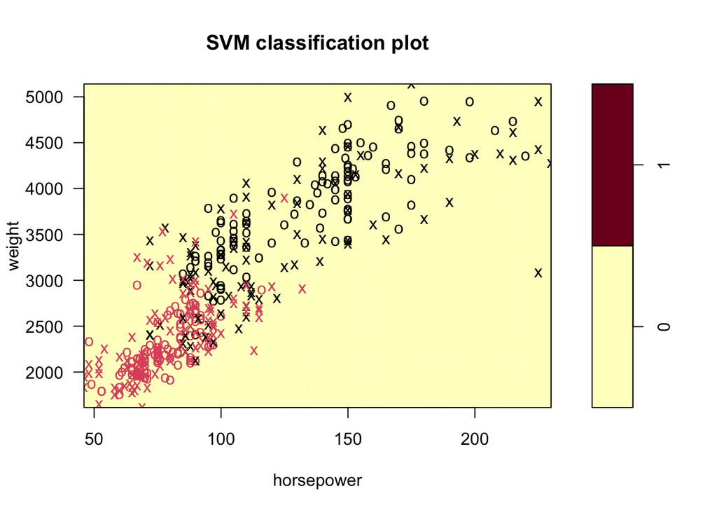

```r
# Radial
plot(tune.out.radial$best.model, Auto_svm, weight ~ horsepower)
```

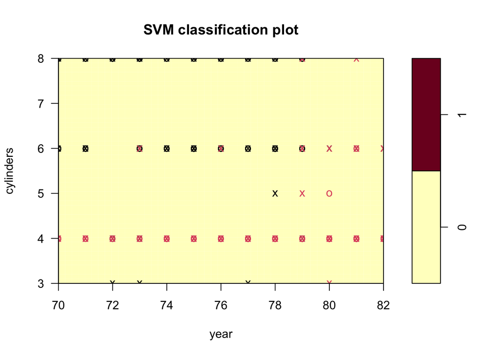

```r
plot(tune.out.radial$best.model, Auto_svm, cylinders ~ year)
```

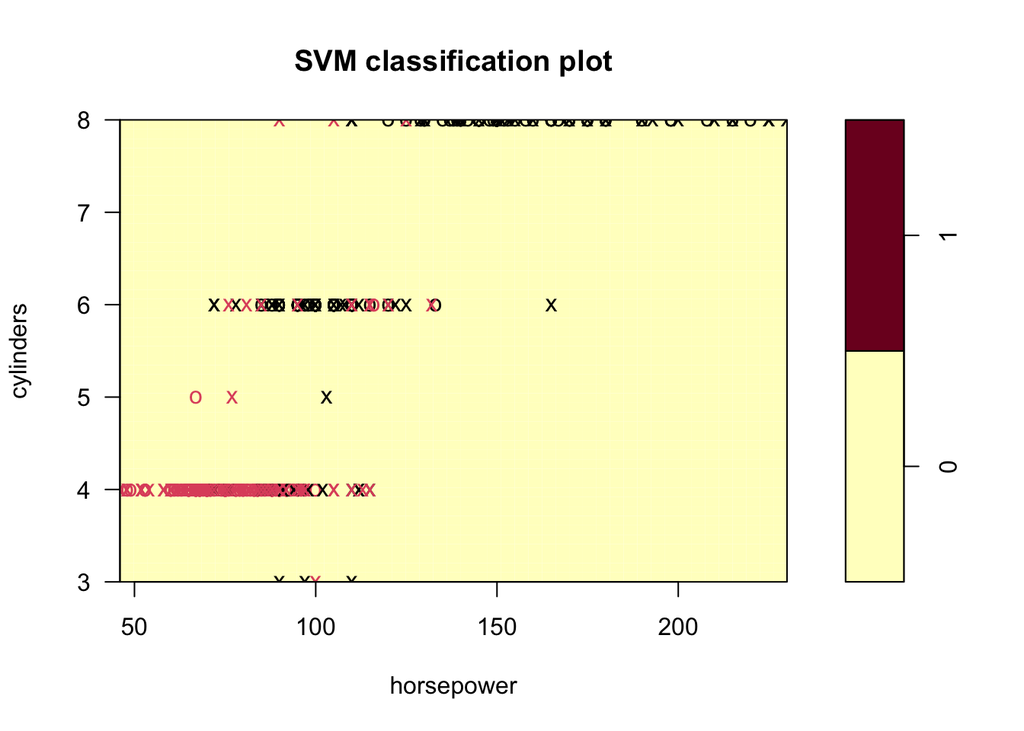

```r
plot(tune.out.radial$best.model, Auto_svm, cylinders ~ horsepower)
```

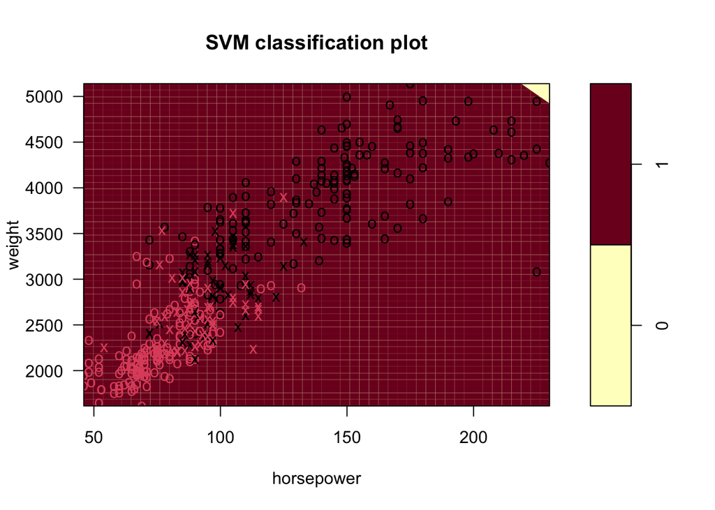

```r
# Polynomial
plot(tune.out.poly$best.model, Auto_svm, weight ~ horsepower)
```

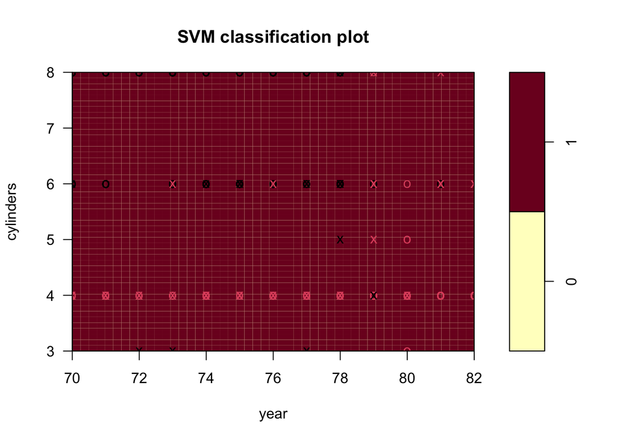

```r
plot(tune.out.poly$best.model, Auto_svm, cylinders ~ year)
```

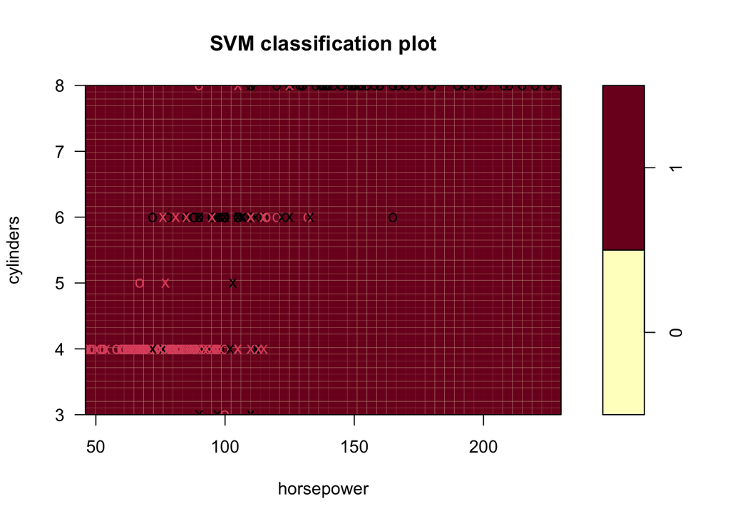

```r
plot(tune.out.poly$best.model, Auto_svm, cylinders ~ horsepower)
```